# AIML Module Project - UnsupervisedLearning - Aaditya Kumar Ravi

### Part A - 30 Marks

*• DOMAIN:* Automobile  
*• CONTEXT:* The data concerns city-cycle fuel consumption in miles per gallon to be predicted in terms of 3 multivalued discrete and 5 continuous attributes.  
*• DATA DESCRIPTION:* | | | |--|--|  
|*cylinders:* multi-valued discrete|*acceleration:* continuous|  
|*displacement:* continuous model|*year:* multi-valued discrete|  
|*horsepower:* continuous|*origin:* multi-valued discrete|  
|*weight:* continuous|*car name:* string (unique for each instance)|  
|*mpg:* continuous| |

*• PROJECT OBJECTIVE:* To understand K-means Clustering by applying on the Car Dataset to segment the cars into various categories.  
*• STEPS AND TASK [30 Marks]:*  
*1. Data Understanding & Exploration: [5 Marks]*

```python
#importing some basic libraries
import numpy as np
import pandas as pd
import matplotlib.pyplot as plt
%matplotlib inline
import seaborn as sns
```

##### A. Read ‘Car name.csv’ as a DataFrame and assign it to a variable. [1 Mark]

```python
cname = pd.read_csv('Car name.csv')
```

```python
cname.head()
```

|  | car_name |
| --- | --- |
| 0 | chevrolet chevelle malibu |
| 1 | buick skylark 320 |
| 2 | plymouth satellite |
| 3 | amc rebel sst |
| 4 | ford torino |

##### B. Read ‘Car-Attributes.json as a DataFrame and assign it to a variable. [1 Mark]

```python
cattribute = pd.read_json('Car-Attributes.json')
```

```python
cattribute.head()
```

|  | mpg | cyl | disp | hp | wt | acc | yr | origin |
| --- | --- | --- | --- | --- | --- | --- | --- | --- |
| 0 | 18.0 | 8 | 307.0 | 130 | 3504 | 12.0 | 70 | 1 |
| 1 | 15.0 | 8 | 350.0 | 165 | 3693 | 11.5 | 70 | 1 |
| 2 | 18.0 | 8 | 318.0 | 150 | 3436 | 11.0 | 70 | 1 |
| 3 | 16.0 | 8 | 304.0 | 150 | 3433 | 12.0 | 70 | 1 |
| 4 | 17.0 | 8 | 302.0 | 140 | 3449 | 10.5 | 70 | 1 |

##### C. Merge both the DataFrames together to form a single DataFrame [2 Mark]

```python
# Let us check the shape of both the dataframes before merging
cname.shape
```

```
(398, 1)
```

```python
cattribute.shape
```

```
(398, 8)
```

- We can see it has same no. of rows i.e 398 in both the dataframes
- Column number defers cname has 1 column and cattribute has 8 attributes.
- After merging we will have 398 rows and 1+8 i.e 9 columns

```python
cardf = pd.merge(cname, cattribute, left_index=True, right_index=True) #merge based on index
```

```python
cardf.shape #verify the shape
```

```
(398, 9)
```

Shape matched as per expectation after merging

```python
cardf.head()
```

|  | car_name | mpg | cyl | disp | hp | wt | acc | yr | origin |
| --- | --- | --- | --- | --- | --- | --- | --- | --- | --- |
| 0 | chevrolet chevelle malibu | 18.0 | 8 | 307.0 | 130 | 3504 | 12.0 | 70 | 1 |
| 1 | buick skylark 320 | 15.0 | 8 | 350.0 | 165 | 3693 | 11.5 | 70 | 1 |
| 2 | plymouth satellite | 18.0 | 8 | 318.0 | 150 | 3436 | 11.0 | 70 | 1 |
| 3 | amc rebel sst | 16.0 | 8 | 304.0 | 150 | 3433 | 12.0 | 70 | 1 |
| 4 | ford torino | 17.0 | 8 | 302.0 | 140 | 3449 | 10.5 | 70 | 1 |

##### D. Print 5 point summary of the numerical features and share insights. [1 Marks]

```python
cardf.info()
```

```
<class 'pandas.core.frame.DataFrame'>
RangeIndex: 398 entries, 0 to 397
Data columns (total 9 columns):
 #   Column    Non-Null Count  Dtype
---  ------    --------------  -----
 0   car_name  398 non-null    object
 1   mpg       398 non-null    float64
 2   cyl       398 non-null    int64
 3   disp      398 non-null    float64
 4   hp        398 non-null    object
 5   wt        398 non-null    int64
 6   acc       398 non-null    float64
 7   yr        398 non-null    int64
 8   origin    398 non-null    int64
dtypes: float64(3), int64(4), object(2)
memory usage: 28.1+ KB
```

- Here carname and hp column is showing of object type.
- carname is string and hence it is object type. that's correct.
- but hp values looks numerical looking at above head() but still its datatype is object above. So may be some unexpected or string value will be there, which we need to treat.

```python
#if we just want to see 5 point summary we can select specific points to display
cardf.describe().loc[['min', '25%', '50%', '75%', 'max']].T
```

|  | min | 25% | 50% | 75% | max |
| --- | --- | --- | --- | --- | --- |
| mpg | 9.0 | 17.500 | 23.0 | 29.000 | 46.6 |
| cyl | 3.0 | 4.000 | 4.0 | 8.000 | 8.0 |
| disp | 68.0 | 104.250 | 148.5 | 262.000 | 455.0 |
| wt | 1613.0 | 2223.750 | 2803.5 | 3608.000 | 5140.0 |
| acc | 8.0 | 13.825 | 15.5 | 17.175 | 24.8 |
| yr | 70.0 | 73.000 | 76.0 | 79.000 | 82.0 |
| origin | 1.0 | 1.000 | 1.0 | 2.000 | 3.0 |

**Insights:**

- mpg(Miles Per Gallon):
  - The 50th percentile of mpg is 23 miles per gallon
  - The majority of the data falls within the range of 17.5 to 29 miles per gallon
  - The minimum observed mpg is 9, and the maximum is 46.6 mpg
- cyl(Number of Cylinders):
  - The most common number of cylinders is 4, as 25th percentile is same as the 50th percentile
  - The range of the number of cylinders is from 3 to 8
- disp(Displacement):
  - The 50th percentile displacement is 148.5
  - The range of displacement is from 68 to 455
  - The interquartile range(IQR) is from 104.25 to 262
- wt(Weight):
  - The median(50th percentile) weight is 2803.5
  - Weight of cars range from 1613 to 5140
- acc(Acceleration):
  - The 50th percentile acceleration is 15.5 units
  - The interquartile range(IQR) is from 13.825 to 17.175
  - The minimum observed acceleration is 8, and the maximum is 24.8
- yr(Model Year):
  - Year ranges from 70 to 82
  - The median is year 76
- origin:
  - The origin appears to be categorical with values 1, 2, and 3
  - The most common origin is 1, as 25th percentile is same as the 50th percentile  
    **Note: Here we don't have hp related insights, it is next to question no 2.H answer after unexpected value is dropped**

##### 2. Data Preparation & Analysis: [10 Marks]

##### A. Check and print feature-wise percentage of missing values present in the data and impute with the best suitable approach. [2 Mark]

```python
cardf.info()
```

```
<class 'pandas.core.frame.DataFrame'>
RangeIndex: 398 entries, 0 to 397
Data columns (total 9 columns):
 #   Column    Non-Null Count  Dtype
---  ------    --------------  -----
 0   car_name  398 non-null    object
 1   mpg       398 non-null    float64
 2   cyl       398 non-null    int64
 3   disp      398 non-null    float64
 4   hp        398 non-null    object
 5   wt        398 non-null    int64
 6   acc       398 non-null    float64
 7   yr        398 non-null    int64
 8   origin    398 non-null    int64
dtypes: float64(3), int64(4), object(2)
memory usage: 28.1+ KB
```

- None of the columns has null value as total record count is 398 and non null is also 398

```python
#check featurewise percentage of missing values
(cardf.isnull().sum()*100)/cardf.shape[0]
```

```
car_name    0.0
mpg         0.0
cyl         0.0
disp        0.0
hp          0.0
wt          0.0
acc         0.0
yr          0.0
origin      0.0
dtype: float64
```

- Since none of the features has any missing or null value, so we won't do any imputation here.

##### B. Check for duplicate values in the data and impute with the best suitable approach. [1 Mark]

```python
cardf.duplicated().sum()
```

```
0
```

- Since we don't have any duplicate values, so we don't need to do any imputation here.

##### C. Plot a pairplot for all features. [1 Marks]

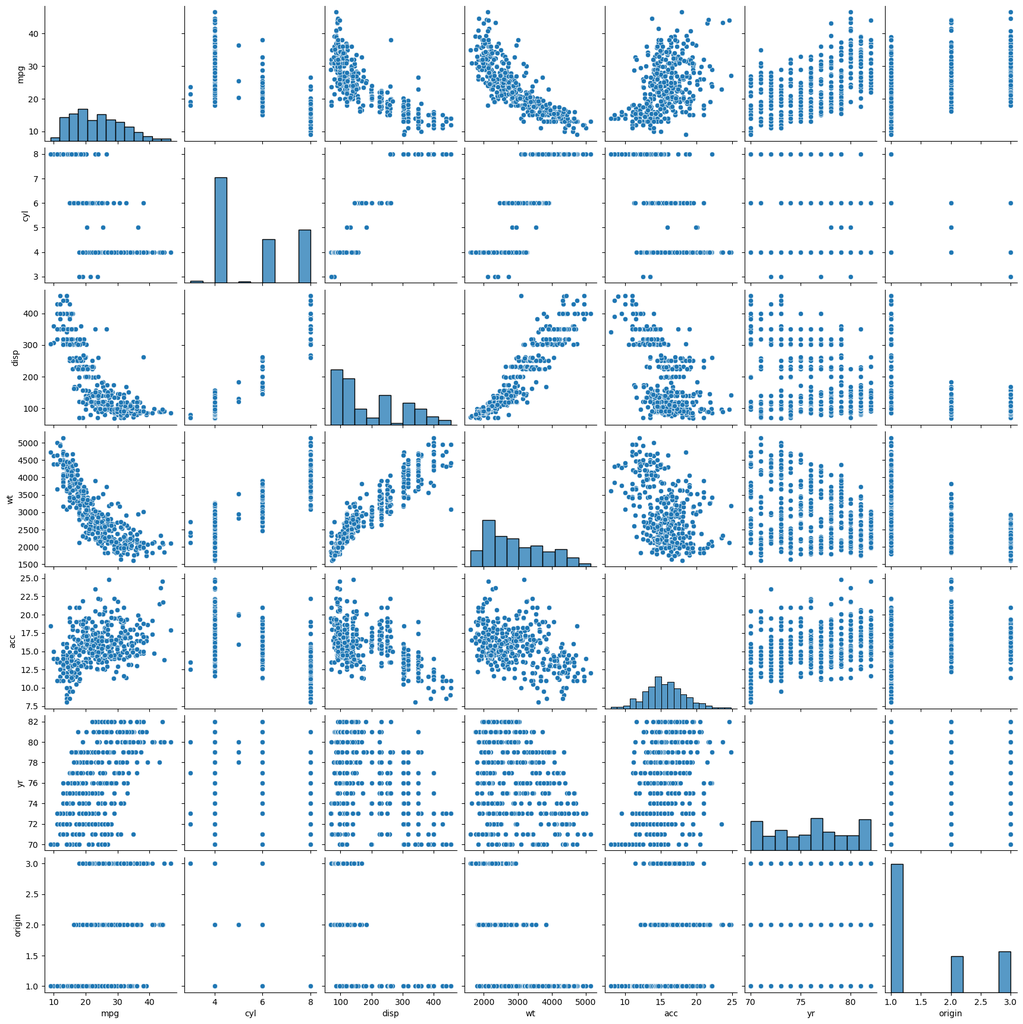

```python
sns.pairplot(cardf)
```

**Insights:**

- Weight and displacement are positively correlated, these are increasing together.
- Weight and milege per gallon are negatively correlated, weight increases then mpg i.e fuel efficiency decreases
- Displacement and milege per gallon are also negatively correlated.
- Displacement and accelleration are also somewhat negatively correlated.  
  **Note: Here we don't have hp related insights, it is next to question no 2.H answer after unexpected value dropped**

##### D. Visualize a scatterplot for ‘wt’ and ‘disp’. Datapoints should be distinguishable by ‘cyl’. [1 Marks]

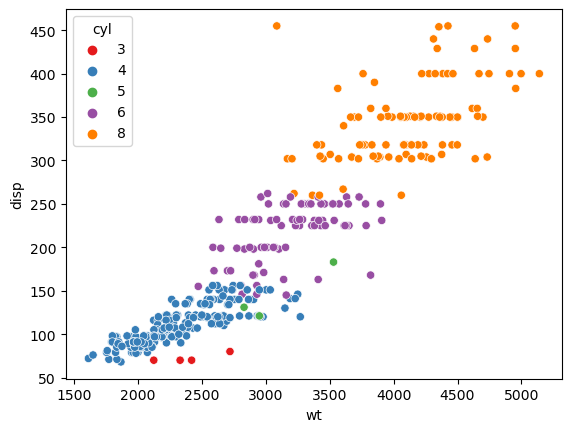

```python
#using palette to distinguish each cylinder count values with a unique color
sns.scatterplot(cardf, x='wt', y='disp', hue='cyl', palette='Set1')
```

##### E. Share insights for Q2.d. [1 Marks]

**Insights:**

- Weight and Displacement are positively correlated. Both are increases together.
- Higher the weight, higher the displacement
- Lower the weight, lower the displacement
- Cars are available with 5 types of cylinders count(3,4,5,6,8)
- Cars with number of cylinders 3 and 5 are very less
- Cars with 4 cylinders are most common, followed by cars having 8 cylinders and then 6 cylinders
- Weight is ranging from around 1600 to 5100
- Displace is ranging from around 60 to 455

##### F. Visualize a scatterplot for ‘wt’ and ’mpg’. Datapoints should be distinguishable by ‘cyl’. [1 Marks]

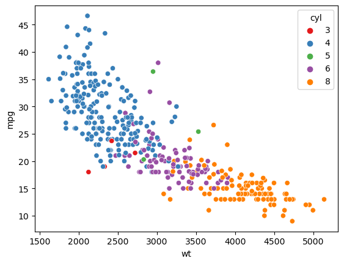

```python
#using palette to distinguish each cylinder count values with a unique color
sns.scatterplot(cardf, x='wt', y='mpg', hue='cyl', palette="Set1")
```

#### G. Share insights for Q2.f. [1 Marks]

**Insights:**

- Weight is ranging from around 1600 to 5100
- mpg(Miles Per Gallon) is ranging from around 5 to 50
- Wt and mpg are negatively correlated. Wt increases, mpg fuel efficiency decreases. if wt is low, fuel efficiency is high.
- Cars are available with 5 types of cylinders count (3,4,5,6,8)
- Cars with 3 and 5 cylinders are less common.
- Cars with 4 cylinders are most common followed by cars with 8 cylinders and then 6 cylinders

##### H. Check for unexpected values in all the features and datapoints with such values. [2 Marks]

```python
cardf.info()
```

```
<class 'pandas.core.frame.DataFrame'>
RangeIndex: 398 entries, 0 to 397
Data columns (total 9 columns):
 #   Column    Non-Null Count  Dtype
---  ------    --------------  -----
 0   car_name  398 non-null    object
 1   mpg       398 non-null    float64
 2   cyl       398 non-null    int64
 3   disp      398 non-null    float64
 4   hp        398 non-null    object
 5   wt        398 non-null    int64
 6   acc       398 non-null    float64
 7   yr        398 non-null    int64
 8   origin    398 non-null    int64
dtypes: float64(3), int64(4), object(2)
memory usage: 28.1+ KB
```

```python
cardf.head()
```

|  | car_name | mpg | cyl | disp | hp | wt | acc | yr | origin |
| --- | --- | --- | --- | --- | --- | --- | --- | --- | --- |
| 0 | chevrolet chevelle malibu | 18.0 | 8 | 307.0 | 130 | 3504 | 12.0 | 70 | 1 |
| 1 | buick skylark 320 | 15.0 | 8 | 350.0 | 165 | 3693 | 11.5 | 70 | 1 |
| 2 | plymouth satellite | 18.0 | 8 | 318.0 | 150 | 3436 | 11.0 | 70 | 1 |
| 3 | amc rebel sst | 16.0 | 8 | 304.0 | 150 | 3433 | 12.0 | 70 | 1 |
| 4 | ford torino | 17.0 | 8 | 302.0 | 140 | 3449 | 10.5 | 70 | 1 |

- We can see though hp is object type but it has numerical values, which means some unexpected string value is there.  
  #### Let us check for the unexpected values for all the numerical columns and hp.

```python
columns = cardf.iloc[:, 1:]
for col in columns:
    print(col, ": ", cardf[col].unique())
    print("==============================")
```

```
mpg :  [18.  15.  16.  17.  14.  24.  22.  21.  27.  26.  25.  10.  11.   9.
 28.  19.  12.  13.  23.  30.  31.  35.  20.  29.  32.  33.  17.5 15.5
 14.5 22.5 24.5 18.5 29.5 26.5 16.5 31.5 36.  25.5 33.5 20.5 30.5 21.5
 43.1 36.1 32.8 39.4 19.9 19.4 20.2 19.2 25.1 20.6 20.8 18.6 18.1 17.7
 27.5 27.2 30.9 21.1 23.2 23.8 23.9 20.3 21.6 16.2 19.8 22.3 17.6 18.2
 16.9 31.9 34.1 35.7 27.4 25.4 34.2 34.5 31.8 37.3 28.4 28.8 26.8 41.5
 38.1 32.1 37.2 26.4 24.3 19.1 34.3 29.8 31.3 37.  32.2 46.6 27.9 40.8
 44.3 43.4 36.4 44.6 40.9 33.8 32.7 23.7 23.6 32.4 26.6 25.8 23.5 39.1
 39.  35.1 32.3 37.7 34.7 34.4 29.9 33.7 32.9 31.6 28.1 30.7 24.2 22.4
 34.  38.  44. ]
==============================
cyl :  [8 4 6 3 5]
==============================
disp :  [307.  350.  318.  304.  302.  429.  454.  440.  455.  390.  383.  340.
 400.  113.  198.  199.  200.   97.  110.  107.  104.  121.  360.  140.
  98.  232.  225.  250.  351.  258.  122.  116.   79.   88.   71.   72.
  91.   97.5  70.  120.   96.  108.  155.   68.  114.  156.   76.   83.
  90.  231.  262.  134.  119.  171.  115.  101.  305.   85.  130.  168.
 111.  260.  151.  146.   80.   78.  105.  131.  163.   89.  267.   86.
 183.  141.  173.  135.   81.  100.  145.  112.  181.  144. ]
==============================
hp :  [130 165 150 140 198 220 215 225 190 170 160 95 97 85 88 46 87 90 113 200
 210 193 '?' 100 105 175 153 180 110 72 86 70 76 65 69 60 80 54 208 155
 112 92 145 137 158 167 94 107 230 49 75 91 122 67 83 78 52 61 93 148 129
 96 71 98 115 53 81 79 120 152 102 108 68 58 149 89 63 48 66 139 103 125
 133 138 135 142 77 62 132 84 64 74 116 82]
==============================
wt :  [3504 3693 3436 3433 3449 4341 4354 4312 4425 3850 3563 3609 3761 3086
 2372 2833 2774 2587 2130 1835 2672 2430 2375 2234 2648 4615 4376 4382
 4732 2264 2228 2046 2634 3439 3329 3302 3288 4209 4464 4154 4096 4955
 4746 5140 2962 2408 3282 3139 2220 2123 2074 2065 1773 1613 1834 1955
 2278 2126 2254 2226 4274 4385 4135 4129 3672 4633 4502 4456 4422 2330
 3892 4098 4294 4077 2933 2511 2979 2189 2395 2288 2506 2164 2100 4100
 3988 4042 3777 4952 4363 4237 4735 4951 3821 3121 3278 2945 3021 2904
 1950 4997 4906 4654 4499 2789 2279 2401 2379 2124 2310 2472 2265 4082
 4278 1867 2158 2582 2868 3399 2660 2807 3664 3102 2875 2901 3336 2451
 1836 2542 3781 3632 3613 4141 4699 4457 4638 4257 2219 1963 2300 1649
 2003 2125 2108 2246 2489 2391 2000 3264 3459 3432 3158 4668 4440 4498
 4657 3907 3897 3730 3785 3039 3221 3169 2171 2639 2914 2592 2702 2223
 2545 2984 1937 3211 2694 2957 2671 1795 2464 2572 2255 2202 4215 4190
```

[output cut: 11 more lines]

```
 2025 1970 2160 2205 2245 1965 1995 3015 2585 2835 2665 2370 2790 2295
 2625]
==============================
acc :  [12.  11.5 11.  10.5 10.   9.   8.5  8.   9.5 15.  15.5 16.  14.5 20.5
 17.5 12.5 14.  13.5 18.5 19.  13.  19.5 18.  17.  23.5 16.5 21.  16.9
 14.9 17.7 15.3 13.9 12.8 15.4 17.6 22.2 22.1 14.2 17.4 16.2 17.8 12.2
 16.4 13.6 15.7 13.2 21.9 16.7 12.1 14.8 18.6 16.8 13.7 11.1 11.4 18.2
 15.8 15.9 14.1 21.5 14.4 19.4 19.2 17.2 18.7 15.1 13.4 11.2 14.7 16.6
 17.3 15.2 14.3 20.1 24.8 11.3 12.9 18.8 18.1 17.9 21.7 23.7 19.9 21.8
 13.8 12.6 16.1 20.7 18.3 20.4 19.6 17.1 15.6 24.6 11.6]
==============================
yr :  [70 71 72 73 74 75 76 77 78 79 80 81 82]
==============================
origin :  [1 3 2]
==============================
```

All the values are having appropriate value except hp which has ?(question mark) somewhere, Let us view the record of ?

```python
cardf.loc[cardf['hp']=='?']
```

|  | car_name | mpg | cyl | disp | hp | wt | acc | yr | origin |
| --- | --- | --- | --- | --- | --- | --- | --- | --- | --- |
| 32 | ford pinto | 25.0 | 4 | 98.0 | ? | 2046 | 19.0 | 71 | 1 |
| 126 | ford maverick | 21.0 | 6 | 200.0 | ? | 2875 | 17.0 | 74 | 1 |
| 330 | renault lecar deluxe | 40.9 | 4 | 85.0 | ? | 1835 | 17.3 | 80 | 2 |
| 336 | ford mustang cobra | 23.6 | 4 | 140.0 | ? | 2905 | 14.3 | 80 | 1 |
| 354 | renault 18i | 34.5 | 4 | 100.0 | ? | 2320 | 15.8 | 81 | 2 |
| 374 | amc concord dl | 23.0 | 4 | 151.0 | ? | 3035 | 20.5 | 82 | 1 |

- We can see 6 values having ?, we will drop these rows.
- Let us first replace ? with null values, then will drop these rows.

```python
cardf['hp']=cardf['hp'].replace('?',np.nan)
cardf.loc[cardf['hp'].isnull()]
```

|  | car_name | mpg | cyl | disp | hp | wt | acc | yr | origin |
| --- | --- | --- | --- | --- | --- | --- | --- | --- | --- |
| 32 | ford pinto | 25.0 | 4 | 98.0 | NaN | 2046 | 19.0 | 71 | 1 |
| 126 | ford maverick | 21.0 | 6 | 200.0 | NaN | 2875 | 17.0 | 74 | 1 |
| 330 | renault lecar deluxe | 40.9 | 4 | 85.0 | NaN | 1835 | 17.3 | 80 | 2 |
| 336 | ford mustang cobra | 23.6 | 4 | 140.0 | NaN | 2905 | 14.3 | 80 | 1 |
| 354 | renault 18i | 34.5 | 4 | 100.0 | NaN | 2320 | 15.8 | 81 | 2 |
| 374 | amc concord dl | 23.0 | 4 | 151.0 | NaN | 3035 | 20.5 | 82 | 1 |

```python
#using drop function to drop the rows having hp value as null and then will reset index
cardf = cardf.drop(cardf.loc[cardf['hp'].isnull()].index).reset_index(drop=True)
```

```python
cardf.isnull().sum()
```

```
car_name    0
mpg         0
cyl         0
disp        0
hp          0
wt          0
acc         0
yr          0
origin      0
dtype: int64
```

We can see now no null values present. Let us see the shape now as 6 rows are deleted, the count should be 398-6=392

```python
cardf.shape
```

```
(392, 9)
```

**Now Let us do some visualizations for hp as it was not done previously due to unexpected values in hp column**

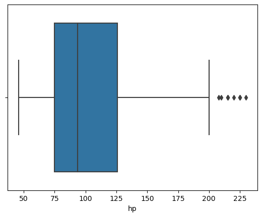

```python
sns.boxplot(cardf, x='hp')
```

```python
cardf.loc[cardf['hp']>200]
```

|  | car_name | mpg | cyl | disp | hp | wt | acc | yr | origin |
| --- | --- | --- | --- | --- | --- | --- | --- | --- | --- |
| 6 | chevrolet impala | 14.0 | 8 | 454.0 | 220.0 | 4354 | 9.0 | 70 | 1 |
| 7 | plymouth fury iii | 14.0 | 8 | 440.0 | 215.0 | 4312 | 8.5 | 70 | 1 |
| 8 | pontiac catalina | 14.0 | 8 | 455.0 | 225.0 | 4425 | 10.0 | 70 | 1 |
| 13 | buick estate wagon (sw) | 14.0 | 8 | 455.0 | 225.0 | 3086 | 10.0 | 70 | 1 |
| 25 | ford f250 | 10.0 | 8 | 360.0 | 215.0 | 4615 | 14.0 | 70 | 1 |
| 27 | dodge d200 | 11.0 | 8 | 318.0 | 210.0 | 4382 | 13.5 | 70 | 1 |
| 66 | mercury marquis | 11.0 | 8 | 429.0 | 208.0 | 4633 | 11.0 | 72 | 1 |
| 93 | chrysler new yorker brougham | 13.0 | 8 | 440.0 | 215.0 | 4735 | 11.0 | 73 | 1 |
| 94 | buick electra 225 custom | 12.0 | 8 | 455.0 | 225.0 | 4951 | 11.0 | 73 | 1 |
| 115 | pontiac grand prix | 16.0 | 8 | 400.0 | 230.0 | 4278 | 9.5 | 73 | 1 |

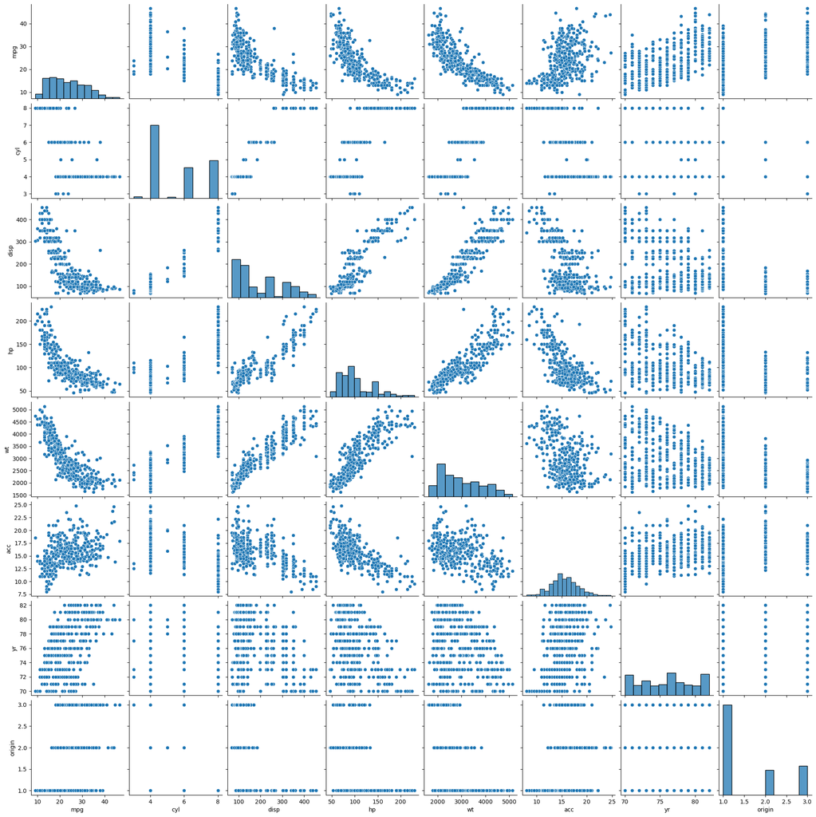

```python
# In the last pair plot we could not see plot for hp as that was of object type that time due to unexpected value.
# Let us draw the pairplot agian
sns.pairplot(cardf)
```

**hp related Insights for Q. 2.C:**

- horsepower is negatively correlated with acceleration and milege per gallon
- whereas horsepower is positively correlated with weight and displacement

```python
cardf['hp'].describe().loc[['min', '25%', '50%', '75%', 'max']]
```

```
min     46.0
25%     75.0
50%     93.5
75%    126.0
max    230.0
Name: hp, dtype: float64
```

**hp related Insights for question 1.D.:**

- horsepwer IQR ranges between 75 to 126
- cars having minimum horsepwer of 46 and max horsepower of 230

##### 3. Clustering: [15 Marks]

##### A. Apply K-Means clustering for 2 to 10 clusters. [3 Marks]

```python
from scipy.stats import zscore

cardfattr = cardf.iloc[:, 1:9] #excluding first column car_name
cardfscaled = cardfattr.apply(zscore) #scaling the dataframe for excluded car_name column
cardfscaled.head() #view the scaled data
```

|  | mpg | cyl | disp | hp | wt | acc | yr | origin |
| --- | --- | --- | --- | --- | --- | --- | --- | --- |
| 0 | -0.698638 | 1.483947 | 1.077290 | 0.664133 | 0.620540 | -1.285258 | -1.625315 | -0.716641 |
| 1 | -1.083498 | 1.483947 | 1.488732 | 1.574594 | 0.843334 | -1.466724 | -1.625315 | -0.716641 |
| 2 | -0.698638 | 1.483947 | 1.182542 | 1.184397 | 0.540382 | -1.648189 | -1.625315 | -0.716641 |
| 3 | -0.955212 | 1.483947 | 1.048584 | 1.184397 | 0.536845 | -1.285258 | -1.625315 | -0.716641 |
| 4 | -0.826925 | 1.483947 | 1.029447 | 0.924265 | 0.555706 | -1.829655 | -1.625315 | -0.716641 |

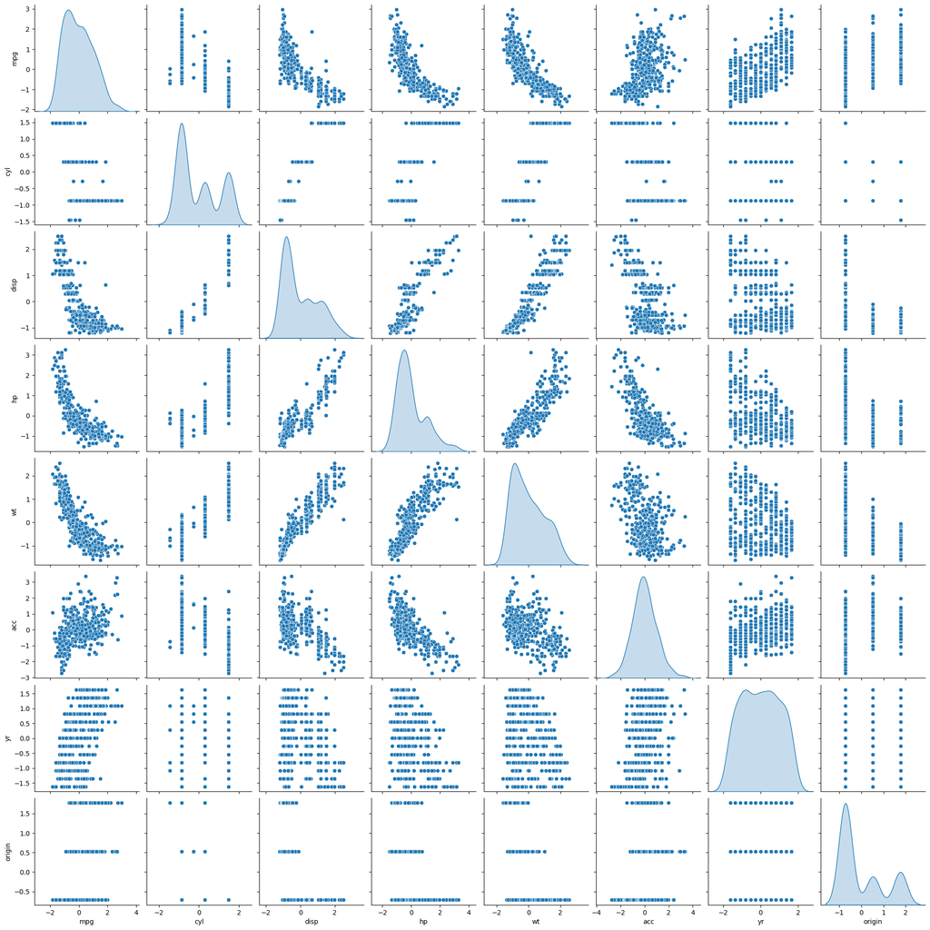

```python
sns.pairplot(cardfscaled,diag_kind='kde') #plot the pairplot
```

```python
#import the required library
from sklearn.cluster import KMeans
from sklearn.metrics import silhouette_samples, silhouette_score
```

```python
wss=[] #within cluster sum of squares
for i in range(2,11):
    km = KMeans(n_clusters=i, n_init='auto') #initialize kmeans clustering
    km.fit(cardfscaled) #fit the kmeans clustering on scaled data
    wss.append(km.inertia_) #sum of squared distances of samples to their closest cluster center
    print("Silhouette Score for cluster", i, ":", silhouette_score(cardfscaled, km.labels_))
```

```
Silhouette Score for cluster 2 : 0.41646208298843823
Silhouette Score for cluster 3 : 0.32273725161098543
Silhouette Score for cluster 4 : 0.3114829939692667
Silhouette Score for cluster 5 : 0.33334406681596646
Silhouette Score for cluster 6 : 0.30870489360847775
Silhouette Score for cluster 7 : 0.3179056267995235
Silhouette Score for cluster 8 : 0.28058141938461295
Silhouette Score for cluster 9 : 0.27091949723799424
Silhouette Score for cluster 10 : 0.26446591683522225
```

##### B. Plot a visual and find elbow point. [2 Marks]

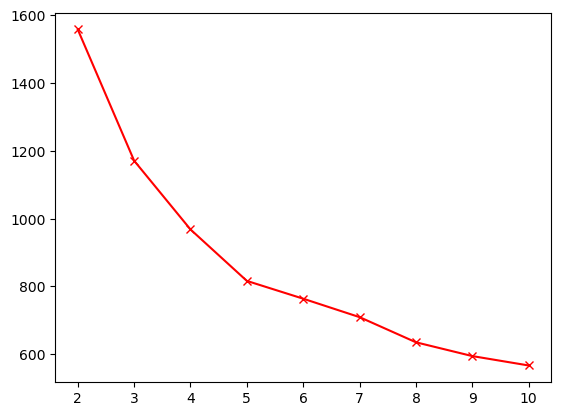

```python
plt.plot(range(2,11), wss, 'rx-')
```

- it looks like elbow point is at cluster 5 because the rate of wss descrease is slow down at this pont and also the silhouette score is good, so the optimal number of clusters for this kMeans clustering is 5

##### C. On the above visual, highlight which are the possible Elbow points. [1 Marks]

- Looking at the above visual, there are 3 points where graph bends like elbow
- First at cluster=3 but this is not an optimal elbow point becuase the wss descrease is still high as it is dropping from 1200 to 800 when we find next elbow point at 5
- Second at cluster=5 which looks like perfect elbow point because comparatively the wss decrease is slow now and silhouette score(0.33) is also better than cluster 3(0.32) and 8(0.28)
- Third at cluster=8 which also doesn't look like perfect elbow point and the silhouette score(0.28) is also less than cluster 5(0.33).

Hence n_cluster=5 is the best elbow point.

##### D. Train a K-means clustering model once again on the optimal number of clusters. [3 Marks]

```python
km_clusters = KMeans(n_clusters=5, n_init='auto') #initialize the kMeans clustering model
km_clusters.fit(cardfscaled) #train the model
```

```
KMeans(n_clusters=5, n_init='auto')
```

```python
#silhouette coefficient for each data point
silhouette_samples(cardfscaled, km_clusters.labels_)
```

```
array([ 0.31142589,  0.51769791,  0.41047911,  0.39902837,  0.37792021,
        0.54132445,  0.49910877,  0.49929448,  0.50333692,  0.50327205,
        0.50422805,  0.44662294,  0.48501995,  0.42449959,  0.37804782,
        0.22879245,  0.26498339,  0.18382714,  0.33296771,  0.26768112,
        0.40785526,  0.44033902,  0.43413863,  0.36709861,  0.19293552,
        0.48578309,  0.43824377,  0.49154275,  0.25495934,  0.31995324,
        0.21662764,  0.34869347,  0.24062698,  0.38480318,  0.40446366,
        0.40995951,  0.41991031,  0.58611268,  0.59276518,  0.52910315,
        0.51252589,  0.56831192,  0.58036885,  0.5489361 ,  0.26431336,
        0.1683629 ,  0.39642071,  0.37459778,  0.24612033,  0.41947645,
        0.27858396,  0.37544773,  0.11134518,  0.04536532,  0.3183338 ,
        0.16228136,  0.35184785,  0.20874583,  0.17934669,  0.0969874 ,
        0.22297724,  0.60451623,  0.60608123,  0.50856968,  0.56478782,
        0.46466532,  0.55503336,  0.55863812,  0.56687211,  0.59104898,
        0.33349389,  0.50045442,  0.36970703,  0.27311349,  0.48079887,
        0.2572998 ,  0.40250283,  0.25330854,  0.38758519,  0.21707579,
        0.25729303,  0.36095344,  0.18546069,  0.27694618,  0.58815425,
        0.48623612,  0.53045125,  0.3556054 ,  0.50288662,  0.55691377,
        0.57691404,  0.58949917,  0.46341604,  0.53993472,  0.5092607 ,
        0.57598303,  0.50036921,  0.50490726,  0.47554661,  0.48188069,
        0.3597902 ,  0.18001475,  0.49369941,  0.57348733,  0.59194672,
        0.5998939 ,  0.42107158,  0.25955263,  0.10843264,  0.32785805,
        0.30362749,  0.13305767,  0.17361403,  0.43272692,  0.53482779,
        0.50162358,  0.1720419 ,  0.43242147,  0.3849772 ,  0.28090642,
        0.44687867,  0.3781939 ,  0.18204323,  0.54706229,  0.48104466,
        0.49512064,  0.53900291,  0.06648673,  0.026916  ,  0.09227982,
        0.0185702 ,  0.49712831,  0.49976536,  0.53610811,  0.3964628 ,
        0.48274257,  0.52053693,  0.2736539 ,  0.34641214,  0.31754327,
        0.34167511,  0.37787976,  0.05987433,  0.098029  ,  0.04162869,
        0.39582418,  0.35828665,  0.27883958,  0.23145393,  0.21179534,
        0.53488473,  0.54371923,  0.37599647,  0.42159407,  0.56639518,
        0.477217  ,  0.42763818,  0.51061861,  0.40938809,  0.49826895,
        0.48821113,  0.49109195,  0.46681838,  0.15091696,  0.23730999,
       -0.02580956,  0.04436935,  0.48965578,  0.04898083,  0.20944262,
        0.31421693,  0.18097315,  0.39711576,  0.2156608 ,  0.5292458 ,
        0.32057908,  0.26243847,  0.28962163,  0.26115494,  0.21023694,
        0.20120586,  0.22346628,  0.1571559 ,  0.15645067,  0.23322353,
        0.39260671,  0.46894634,  0.18199591,  0.51657803,  0.45292803,
        0.44369307,  0.29318941,  0.42122524,  0.1094963 ,  0.09035774,
        0.13556657,  0.29070789,  0.51569729,  0.36662004,  0.52390816,
```

[output cut: 24 more lines]

```
        0.4092987 ,  0.38254191,  0.45256945,  0.1754271 ,  0.12799886,
        0.04537767,  0.0486965 ,  0.38840394,  0.50629109,  0.10858135,
        0.12625944,  0.09616596,  0.06592285,  0.4934648 ,  0.50085932,
        0.47761874,  0.41509855,  0.04924281,  0.38931742,  0.49389139,
        0.22074354,  0.50631341,  0.49473911,  0.45633587,  0.51319407,
        0.51776032,  0.34840559,  0.34271172,  0.29965475,  0.08633811,
        0.45771401,  0.48991888,  0.38247014,  0.41130195,  0.09853786,
        0.06172554,  0.11153321,  0.10746339,  0.21659231,  0.26707367,
        0.14040515,  0.27253197,  0.39165656,  0.4363272 ,  0.37101414,
        0.45337325,  0.47747504,  0.4366693 ,  0.39124049,  0.15351467,
        0.47618837,  0.45779034,  0.26296278,  0.30426682,  0.42758346,
        0.44694632,  0.48541011,  0.46573382,  0.46997434,  0.49068343,
        0.06556061,  0.19999973,  0.4244456 ,  0.05740487,  0.32406845,
        0.30855591,  0.42416946,  0.46600267,  0.11311232,  0.2999369 ,
        0.43248826,  0.38048623])
```

```python
#the average silhouette coefficient for all samples
silhouette_score(cardfscaled, km_clusters.labels_)
```

```
0.3339214769609638
```

##### E. Add a new feature in the DataFrame which will have labels based upon cluster value. [2 Marks]

```python
#Let us add new column for cluster labels in original dataframe cardf
cardf['cluster'] = km_clusters.labels_
cardf.head()
```

|  | car_name | mpg | cyl | disp | hp | wt | acc | yr | origin | cluster |
| --- | --- | --- | --- | --- | --- | --- | --- | --- | --- | --- |
| 0 | chevrolet chevelle malibu | 18.0 | 8 | 307.0 | 130.0 | 3504 | 12.0 | 70 | 1 | 0 |
| 1 | buick skylark 320 | 15.0 | 8 | 350.0 | 165.0 | 3693 | 11.5 | 70 | 1 | 0 |
| 2 | plymouth satellite | 18.0 | 8 | 318.0 | 150.0 | 3436 | 11.0 | 70 | 1 | 0 |
| 3 | amc rebel sst | 16.0 | 8 | 304.0 | 150.0 | 3433 | 12.0 | 70 | 1 | 0 |
| 4 | ford torino | 17.0 | 8 | 302.0 | 140.0 | 3449 | 10.5 | 70 | 1 | 0 |

```python
#Let us read the cluster count
cardf['cluster'].value_counts()
```

```
0    94
2    83
3    80
4    70
1    65
Name: cluster, dtype: int64
```

- We can see there are 5 clusters labeled from 0 to 4 as result of KMeans clustering and highest count of datapoint is in cluster 0.

##### F. Plot a visual and color the datapoints based upon clusters. [2 Marks]

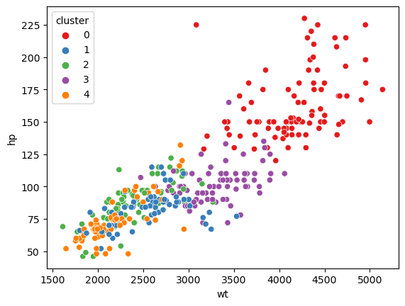

```python
#Let us plot scatter plot
sns.scatterplot(cardf,x='wt',y='hp',hue='cluster', palette="Set1")
```

**Insights:**

- Cluster 0 is best separated followed by cluster 3
- Cluster 1, 2 and 4 is quite messy here but still the clustering is done considering other attributes as well and not only the weight and horsepower.
- Silhoutte score could be better up to 1, here it is just 0.33 which is ok but not the best.

##### G. Pass a new DataPoint and predict which cluster it belongs to. [2 Marks]

```python
# Let us create a datapoint with below data:
sampledata = pd.DataFrame({
    'car_name':['ford pinto'],
    'mpg':25.0,
    'cyl':4,
    'disp':98.0,
    'hp':78,
    'wt':2046,
    'acc':19.0,
    'yr':71,
    'origin':1
})

#read the added datapoint
sampledata.head()
```

|  | car_name | mpg | cyl | disp | hp | wt | acc | yr | origin |
| --- | --- | --- | --- | --- | --- | --- | --- | --- | --- |
| 0 | ford pinto | 25.0 | 4 | 98.0 | 78 | 2046 | 19.0 | 71 | 1 |

```python
cardf_copy = cardf.drop(columns=['cluster']).copy() #create copy of cardf dataset without cluster column
cardf_copy.head()
```

|  | car_name | mpg | cyl | disp | hp | wt | acc | yr | origin |
| --- | --- | --- | --- | --- | --- | --- | --- | --- | --- |
| 0 | chevrolet chevelle malibu | 18.0 | 8 | 307.0 | 130.0 | 3504 | 12.0 | 70 | 1 |
| 1 | buick skylark 320 | 15.0 | 8 | 350.0 | 165.0 | 3693 | 11.5 | 70 | 1 |
| 2 | plymouth satellite | 18.0 | 8 | 318.0 | 150.0 | 3436 | 11.0 | 70 | 1 |
| 3 | amc rebel sst | 16.0 | 8 | 304.0 | 150.0 | 3433 | 12.0 | 70 | 1 |
| 4 | ford torino | 17.0 | 8 | 302.0 | 140.0 | 3449 | 10.5 | 70 | 1 |

```python
#Now let us concatenate cardf_copy dataset with sampledata
cardfcopy_sampledata = pd.concat([cardf_copy,sampledata], ignore_index=True)
cardfcopy_sampledata.tail() #tail it to view last concatenated row which belongs to sampledata
```

|  | car_name | mpg | cyl | disp | hp | wt | acc | yr | origin |
| --- | --- | --- | --- | --- | --- | --- | --- | --- | --- |
| 388 | vw pickup | 44.0 | 4 | 97.0 | 52.0 | 2130 | 24.6 | 82 | 2 |
| 389 | dodge rampage | 32.0 | 4 | 135.0 | 84.0 | 2295 | 11.6 | 82 | 1 |
| 390 | ford ranger | 28.0 | 4 | 120.0 | 79.0 | 2625 | 18.6 | 82 | 1 |
| 391 | chevy s-10 | 31.0 | 4 | 119.0 | 82.0 | 2720 | 19.4 | 82 | 1 |
| 392 | ford pinto | 25.0 | 4 | 98.0 | 78.0 | 2046 | 19.0 | 71 | 1 |

```python
cardfcopy_sampledataattr = cardfcopy_sampledata.iloc[:, 1:9] #excluding first column car_name
csscaled = cardfcopy_sampledataattr.apply(zscore)
```

```python
csscaled.tail() #view the scaled dataset
```

|  | mpg | cyl | disp | hp | wt | acc | yr | origin |
| --- | --- | --- | --- | --- | --- | --- | --- | --- |
| 388 | 2.639533 | -0.862095 | -0.929910 | -1.364059 | -0.996083 | 3.282095 | 1.638130 | 0.528534 |
| 389 | 1.098209 | -0.862095 | -0.566241 | -0.531078 | -0.801631 | -1.432583 | 1.638130 | -0.715262 |
| 390 | 0.584435 | -0.862095 | -0.709794 | -0.661232 | -0.412726 | 1.106090 | 1.638130 | -0.715262 |
| 391 | 0.969766 | -0.862095 | -0.719365 | -0.583140 | -0.300769 | 1.396224 | 1.638130 | -0.715262 |
| 392 | 0.199104 | -0.862095 | -0.920340 | -0.687262 | -1.095077 | 1.251157 | -1.348642 | -0.715262 |

```python
km = KMeans(n_clusters=5, n_init='auto')
km.fit(csscaled)
silhouette_score(csscaled, km.labels_)
```

```
0.33363062575194014
```

Let us add column in cardfcopy_sampledata for cluster predicted. from there we will see the cluster prediction for sample data

```python
cardfcopy_sampledata['cluster'] = km.labels_
cardfcopy_sampledata.tail()
```

|  | car_name | mpg | cyl | disp | hp | wt | acc | yr | origin | cluster |
| --- | --- | --- | --- | --- | --- | --- | --- | --- | --- | --- |
| 388 | vw pickup | 44.0 | 4 | 97.0 | 52.0 | 2130 | 24.6 | 82 | 2 | 1 |
| 389 | dodge rampage | 32.0 | 4 | 135.0 | 84.0 | 2295 | 11.6 | 82 | 1 | 4 |
| 390 | ford ranger | 28.0 | 4 | 120.0 | 79.0 | 2625 | 18.6 | 82 | 1 | 4 |
| 391 | chevy s-10 | 31.0 | 4 | 119.0 | 82.0 | 2720 | 19.4 | 82 | 1 | 4 |
| 392 | ford pinto | 25.0 | 4 | 98.0 | 78.0 | 2046 | 19.0 | 71 | 1 | 2 |

**We can see the cluster prediction is 2 for sample data which is at index 392. So Sample Data passed belongs to cluster 2**

### Part B - 30 Marks

*• DOMAIN:* Automobile  
*• CONTEXT:* The purpose is to classify a given silhouette as one of three types of vehicle, using a set of features extracted from the silhouette. The vehicle may be viewed from one of many different angles.  
*• DATA DESCRIPTION:* The data contains features extracted from the silhouette of vehicles in different angles. Four "Corgie" model vehicles were used for the experiment: a double decker bus, Cheverolet van, Saab 9000 and an Opel Manta 400 cars. This particular combination of vehicles was chosen with the expectation that the bus, van and either one of the cars would be readily distinguishable, but it would be more difficult to distinguish between the cars.  
• All the features are numeric i.e. geometric features extracted from the silhouette.  
*• PROJECT OBJECTIVE:* Apply dimensionality reduction technique – PCA and train a model and compare relative results.  
*• STEPS AND TASK [30 Marks]:*

##### 1. Data Understanding & Cleaning: [5 Marks]

##### A. Read ‘vehicle.csv’ and save as DataFrame. [1 Marks]

```python
vehicle_df = pd.read_csv('vehicle.csv') #read the csv file
vehicle_df.head() #head the read data
```

|  | compactness | circularity | distance_circularity | radius_ratio | pr.axis_aspect_ratio | max.length_aspect_ratio | scatter_ratio | elongatedness | pr.axis_rectangularity | max.length_rectangularity | scaled_variance | scaled_variance.1 | scaled_radius_of_gyration | scaled_radius_of_gyration.1 | skewness_about | skewness_about.1 | skewness_about.2 | hollows_ratio | class |
| --- | --- | --- | --- | --- | --- | --- | --- | --- | --- | --- | --- | --- | --- | --- | --- | --- | --- | --- | --- |
| 0 | 95 | 48.0 | 83.0 | 178.0 | 72.0 | 10 | 162.0 | 42.0 | 20.0 | 159 | 176.0 | 379.0 | 184.0 | 70.0 | 6.0 | 16.0 | 187.0 | 197 | van |
| 1 | 91 | 41.0 | 84.0 | 141.0 | 57.0 | 9 | 149.0 | 45.0 | 19.0 | 143 | 170.0 | 330.0 | 158.0 | 72.0 | 9.0 | 14.0 | 189.0 | 199 | van |
| 2 | 104 | 50.0 | 106.0 | 209.0 | 66.0 | 10 | 207.0 | 32.0 | 23.0 | 158 | 223.0 | 635.0 | 220.0 | 73.0 | 14.0 | 9.0 | 188.0 | 196 | car |
| 3 | 93 | 41.0 | 82.0 | 159.0 | 63.0 | 9 | 144.0 | 46.0 | 19.0 | 143 | 160.0 | 309.0 | 127.0 | 63.0 | 6.0 | 10.0 | 199.0 | 207 | van |
| 4 | 85 | 44.0 | 70.0 | 205.0 | 103.0 | 52 | 149.0 | 45.0 | 19.0 | 144 | 241.0 | 325.0 | 188.0 | 127.0 | 9.0 | 11.0 | 180.0 | 183 | bus |

```python
vehicle_df.info()
```

```
<class 'pandas.core.frame.DataFrame'>
RangeIndex: 846 entries, 0 to 845
Data columns (total 19 columns):
 #   Column                       Non-Null Count  Dtype
---  ------                       --------------  -----
 0   compactness                  846 non-null    int64
 1   circularity                  841 non-null    float64
 2   distance_circularity         842 non-null    float64
 3   radius_ratio                 840 non-null    float64
 4   pr.axis_aspect_ratio         844 non-null    float64
 5   max.length_aspect_ratio      846 non-null    int64
 6   scatter_ratio                845 non-null    float64
 7   elongatedness                845 non-null    float64
 8   pr.axis_rectangularity       843 non-null    float64
 9   max.length_rectangularity    846 non-null    int64
 10  scaled_variance              843 non-null    float64
 11  scaled_variance.1            844 non-null    float64
 12  scaled_radius_of_gyration    844 non-null    float64
 13  scaled_radius_of_gyration.1  842 non-null    float64
 14  skewness_about               840 non-null    float64
 15  skewness_about.1             845 non-null    float64
 16  skewness_about.2             845 non-null    float64
 17  hollows_ratio                846 non-null    int64
 18  class                        846 non-null    object
dtypes: float64(14), int64(4), object(1)
memory usage: 125.7+ KB
```

```python
vehicle_df.shape
```

```
(846, 19)
```

**Observations:**

- All the attributes has numerical values except class.
- Total 846 rows and 19 columns
- Null values are also present in a few columns

##### B. Check percentage of missing values and impute with correct approach. [1 Marks]

```python
vehicle_df.isnull().sum()*100/vehicle_df.shape[0] #print the percentage of missing values (missing*100/total)
```

```
compactness                    0.000000
circularity                    0.591017
distance_circularity           0.472813
radius_ratio                   0.709220
pr.axis_aspect_ratio           0.236407
max.length_aspect_ratio        0.000000
scatter_ratio                  0.118203
elongatedness                  0.118203
pr.axis_rectangularity         0.354610
max.length_rectangularity      0.000000
scaled_variance                0.354610
scaled_variance.1              0.236407
scaled_radius_of_gyration      0.236407
scaled_radius_of_gyration.1    0.472813
skewness_about                 0.709220
skewness_about.1               0.118203
skewness_about.2               0.118203
hollows_ratio                  0.000000
class                          0.000000
dtype: float64
```

- We can see only 5 columns are there which does not have any missing values
- All other columns have less than 1% missing values, exact figure shown above in percentage

```python
#print rows with any missing values to do some analysis
vehicle_df.loc[vehicle_df.isnull().any(axis=1)]
```

|  | compactness | circularity | distance_circularity | radius_ratio | pr.axis_aspect_ratio | max.length_aspect_ratio | scatter_ratio | elongatedness | pr.axis_rectangularity | max.length_rectangularity | scaled_variance | scaled_variance.1 | scaled_radius_of_gyration | scaled_radius_of_gyration.1 | skewness_about | skewness_about.1 | skewness_about.2 | hollows_ratio | class |
| --- | --- | --- | --- | --- | --- | --- | --- | --- | --- | --- | --- | --- | --- | --- | --- | --- | --- | --- | --- |
| 5 | 107 | NaN | 106.0 | 172.0 | 50.0 | 6 | 255.0 | 26.0 | 28.0 | 169 | 280.0 | 957.0 | 264.0 | 85.0 | 5.0 | 9.0 | 181.0 | 183 | bus |
| 9 | 93 | 44.0 | 98.0 | NaN | 62.0 | 11 | 183.0 | 36.0 | 22.0 | 146 | 202.0 | 505.0 | 152.0 | 64.0 | 4.0 | 14.0 | 195.0 | 204 | car |
| 19 | 101 | 56.0 | 100.0 | 215.0 | NaN | 10 | 208.0 | 32.0 | 24.0 | 169 | 227.0 | 651.0 | 223.0 | 74.0 | 6.0 | 5.0 | 186.0 | 193 | car |
| 35 | 100 | 46.0 | NaN | 172.0 | 67.0 | 9 | 157.0 | 43.0 | 20.0 | 150 | 170.0 | 363.0 | 184.0 | 67.0 | 17.0 | 7.0 | 192.0 | 200 | van |
| 66 | 81 | 43.0 | 68.0 | 125.0 | 57.0 | 8 | 149.0 | 46.0 | 19.0 | 146 | 169.0 | 323.0 | 172.0 | NaN | NaN | 18.0 | 179.0 | 184 | bus |
| 70 | 96 | 55.0 | 98.0 | 161.0 | 54.0 | 10 | 215.0 | 31.0 | NaN | 175 | 226.0 | 683.0 | 221.0 | 76.0 | 3.0 | 6.0 | 185.0 | 193 | car |
| 77 | 86 | 40.0 | 62.0 | 140.0 | 62.0 | 7 | 150.0 | 45.0 | 19.0 | 133 | 165.0 | 330.0 | 173.0 | NaN | 2.0 | 3.0 | 180.0 | 185 | car |
| 78 | 104 | 52.0 | 94.0 | NaN | 66.0 | 5 | 208.0 | 31.0 | 24.0 | 161 | 227.0 | 666.0 | 218.0 | 76.0 | 11.0 | 4.0 | 193.0 | 191 | bus |
| 105 | 108 | NaN | 103.0 | 202.0 | 64.0 | 10 | 220.0 | 30.0 | 25.0 | 168 | NaN | 711.0 | 214.0 | 73.0 | 11.0 | NaN | 188.0 | 199 | car |
| 118 | 85 | NaN | NaN | 128.0 | 56.0 | 8 | 150.0 | 46.0 | 19.0 | 144 | 168.0 | 324.0 | 173.0 | 82.0 | 9.0 | 14.0 | 180.0 | 184 | bus |
| 141 | 81 | 42.0 | 63.0 | 125.0 | 55.0 | 8 | 149.0 | 46.0 | 19.0 | 145 | 166.0 | 320.0 | 172.0 | 86.0 | NaN | 7.0 | 179.0 | 182 | bus |
| 159 | 91 | 45.0 | 75.0 | NaN | 57.0 | 6 | 150.0 | 44.0 | 19.0 | 146 | 170.0 | 335.0 | 180.0 | 66.0 | 16.0 | 2.0 | 193.0 | 198 | car |
| 177 | 89 | 44.0 | 72.0 | 160.0 | 66.0 | 7 | 144.0 | 46.0 | 19.0 | 147 | 166.0 | 312.0 | 169.0 | 69.0 | NaN | 1.0 | 191.0 | 198 | bus |
| 192 | 93 | 43.0 | 76.0 | 149.0 | 57.0 | 7 | 149.0 | 44.0 | 19.0 | 143 | 172.0 | 335.0 | 176.0 | NaN | 14.0 | 0.0 | 189.0 | 194 | car |
| 207 | 85 | 42.0 | NaN | 121.0 | 55.0 | 7 | 149.0 | 46.0 | 19.0 | 146 | 167.0 | 323.0 | NaN | 85.0 | 1.0 | 6.0 | 179.0 | 182 | bus |
| 215 | 90 | 39.0 | 86.0 | 169.0 | 62.0 | 7 | 162.0 | NaN | 20.0 | 131 | 194.0 | 388.0 | 147.0 | 74.0 | 1.0 | 22.0 | 185.0 | 191 | car |
| 222 | 100 | 50.0 | 81.0 | 197.0 | NaN | 6 | 186.0 | 34.0 | 22.0 | 158 | 206.0 | 531.0 | 198.0 | 74.0 | NaN | 1.0 | 197.0 | 198 | bus |
| 237 | 85 | 45.0 | 65.0 | 128.0 | 56.0 | 8 | 151.0 | 45.0 | NaN | 145 | 170.0 | 332.0 | 186.0 | 81.0 | 1.0 | 10.0 | 179.0 | 184 | bus |
| 249 | 85 | 34.0 | 53.0 | 127.0 | 58.0 | 6 | NaN | 58.0 | 17.0 | 121 | 137.0 | 197.0 | 127.0 | 70.0 | NaN | 20.0 | 185.0 | 189 | car |
| 266 | 86 | NaN | 65.0 | 116.0 | 53.0 | 6 | 152.0 | 45.0 | 19.0 | 141 | 175.0 | 335.0 | NaN | 85.0 | 5.0 | 4.0 | 179.0 | 183 | bus |
| 273 | 96 | 45.0 | 80.0 | 162.0 | 63.0 | 9 | 146.0 | 46.0 | NaN | 148 | 161.0 | 316.0 | 161.0 | 64.0 | 5.0 | 10.0 | 199.0 | 207 | van |
| 285 | 89 | 48.0 | 85.0 | 189.0 | 64.0 | 8 | 169.0 | 39.0 | 20.0 | 153 | 188.0 | 427.0 | 190.0 | 64.0 | NaN | 5.0 | 195.0 | 201 | car |
| 287 | 88 | 43.0 | 84.0 | NaN | 55.0 | 11 | 154.0 | 44.0 | 19.0 | 150 | 174.0 | 350.0 | 164.0 | 73.0 | 6.0 | 2.0 | 185.0 | 196 | van |
| 308 | 109 | 51.0 | 100.0 | 197.0 | 59.0 | 10 | 192.0 | 34.0 | 22.0 | 161 | 210.0 | NaN | 195.0 | 64.0 | 14.0 | 3.0 | 196.0 | 202 | car |
| 319 | 102 | 51.0 | NaN | 194.0 | 60.0 | 6 | 220.0 | 30.0 | 25.0 | 162 | 247.0 | 731.0 | 209.0 | 80.0 | 7.0 | 7.0 | 188.0 | 186 | bus |
| 329 | 89 | 38.0 | 80.0 | 169.0 | 59.0 | 7 | 161.0 | 41.0 | 20.0 | 131 | 186.0 | 389.0 | 137.0 | NaN | 5.0 | 15.0 | 192.0 | 197 | car |
| 345 | 101 | 54.0 | 106.0 | NaN | 57.0 | 7 | 236.0 | 28.0 | 26.0 | 164 | 256.0 | 833.0 | 253.0 | 81.0 | 6.0 | 14.0 | 185.0 | 185 | bus |
| 372 | 97 | 47.0 | 87.0 | 164.0 | 64.0 | 9 | 156.0 | 43.0 | 20.0 | 149 | NaN | 359.0 | 182.0 | 68.0 | 1.0 | 13.0 | 192.0 | 202 | van |
| 396 | 108 | NaN | 106.0 | 177.0 | 51.0 | 5 | 256.0 | 26.0 | 28.0 | 170 | 285.0 | 966.0 | 261.0 | 87.0 | 11.0 | 2.0 | 182.0 | 181 | bus |
| 419 | 93 | 34.0 | 72.0 | 144.0 | 56.0 | 6 | 133.0 | 50.0 | 18.0 | 123 | 158.0 | 263.0 | 125.0 | 63.0 | 5.0 | 20.0 | NaN | 206 | car |
| 467 | 96 | 54.0 | 104.0 | NaN | 58.0 | 10 | 215.0 | 31.0 | 24.0 | 175 | 221.0 | 682.0 | 222.0 | 75.0 | 13.0 | 23.0 | 186.0 | 194 | car |
| 496 | 106 | 55.0 | 98.0 | 224.0 | 68.0 | 11 | 215.0 | 31.0 | 24.0 | 170 | 222.0 | NaN | 214.0 | 68.0 | 2.0 | 29.0 | 189.0 | 201 | car |
| 522 | 89 | 36.0 | 69.0 | 162.0 | 63.0 | 6 | 140.0 | 48.0 | 18.0 | 131 | NaN | 291.0 | 126.0 | 66.0 | 1.0 | 38.0 | 193.0 | 204 | car |

- Random cell has null values and all null don't belong to any one row or column.
- We will replace null values with median of each column

```python
null_columns = vehicle_df.columns[vehicle_df.isnull().any()] #find columns containing null values
for col in null_columns:
    vehicle_df[col] = vehicle_df[col].fillna(vehicle_df[col].median()) #replace null with mdeian of that column
```

```python
vehicle_df.isnull().sum()*100/vehicle_df.shape[0] #make sure none of the values are left with null
```

```
compactness                    0.0
circularity                    0.0
distance_circularity           0.0
radius_ratio                   0.0
pr.axis_aspect_ratio           0.0
max.length_aspect_ratio        0.0
scatter_ratio                  0.0
elongatedness                  0.0
pr.axis_rectangularity         0.0
max.length_rectangularity      0.0
scaled_variance                0.0
scaled_variance.1              0.0
scaled_radius_of_gyration      0.0
scaled_radius_of_gyration.1    0.0
skewness_about                 0.0
skewness_about.1               0.0
skewness_about.2               0.0
hollows_ratio                  0.0
class                          0.0
dtype: float64
```

We have successfully imputed null values with median

##### C. Visualize a Pie-chart and print percentage of values for variable ‘class’. [2 Marks]

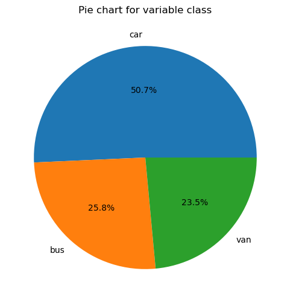

```python
category_count = vehicle_df['class'].value_counts()

plt.figure(figsize=(6,6))
plt.pie(category_count, labels=category_count.index, autopct='%1.1f%%');
plt.title("Pie chart for variable class");
plt.show()
```

**Insights:**

- 50.7% of the vehicles are car in the dataset
- Van and Bus has slight difference(2.3%) in their percentages
- 25.8% are busses and 23.5% are vans in the dataset

##### D. Check for duplicate rows in the data and impute with correct approach. [1 Marks]

```python
vehicle_df.duplicated().sum()
```

```
0
```

It does not have any duplicate rows. so no need to impute anything here.

##### 2. Data Preparation: [2 Marks]

##### A. Split data into X and Y. [Train and Test optional] [1 Marks]

```python
vehicle_df.head()
```

|  | compactness | circularity | distance_circularity | radius_ratio | pr.axis_aspect_ratio | max.length_aspect_ratio | scatter_ratio | elongatedness | pr.axis_rectangularity | max.length_rectangularity | scaled_variance | scaled_variance.1 | scaled_radius_of_gyration | scaled_radius_of_gyration.1 | skewness_about | skewness_about.1 | skewness_about.2 | hollows_ratio | class |
| --- | --- | --- | --- | --- | --- | --- | --- | --- | --- | --- | --- | --- | --- | --- | --- | --- | --- | --- | --- |
| 0 | 95 | 48.0 | 83.0 | 178.0 | 72.0 | 10 | 162.0 | 42.0 | 20.0 | 159 | 176.0 | 379.0 | 184.0 | 70.0 | 6.0 | 16.0 | 187.0 | 197 | van |
| 1 | 91 | 41.0 | 84.0 | 141.0 | 57.0 | 9 | 149.0 | 45.0 | 19.0 | 143 | 170.0 | 330.0 | 158.0 | 72.0 | 9.0 | 14.0 | 189.0 | 199 | van |
| 2 | 104 | 50.0 | 106.0 | 209.0 | 66.0 | 10 | 207.0 | 32.0 | 23.0 | 158 | 223.0 | 635.0 | 220.0 | 73.0 | 14.0 | 9.0 | 188.0 | 196 | car |
| 3 | 93 | 41.0 | 82.0 | 159.0 | 63.0 | 9 | 144.0 | 46.0 | 19.0 | 143 | 160.0 | 309.0 | 127.0 | 63.0 | 6.0 | 10.0 | 199.0 | 207 | van |
| 4 | 85 | 44.0 | 70.0 | 205.0 | 103.0 | 52 | 149.0 | 45.0 | 19.0 | 144 | 241.0 | 325.0 | 188.0 | 127.0 | 9.0 | 11.0 | 180.0 | 183 | bus |

Here class is the categorical target variable for prediction, so we will map the values car with 0, bus with 1 and van with 2 and will change the datatype to numeric before scaling further.

```python
vehicle_dfc = vehicle_df.copy() #copy the original dataset
vehicle_dfc['class']=vehicle_dfc['class'].map({'car':0,'bus':1,'van':2}).astype('int')
```

```python
vehicle_dfc['class'].value_counts()
```

```
0    429
1    218
2    199
Name: class, dtype: int64
```

```python
vehicle_dfc['class'].dtype
```

```
dtype('int32')
```

```python
X = vehicle_dfc.drop('class', axis=1) #X should contain all columns except class
Y = vehicle_dfc['class'] #Y should contain only class column
X.head() #view the X data
```

|  | compactness | circularity | distance_circularity | radius_ratio | pr.axis_aspect_ratio | max.length_aspect_ratio | scatter_ratio | elongatedness | pr.axis_rectangularity | max.length_rectangularity | scaled_variance | scaled_variance.1 | scaled_radius_of_gyration | scaled_radius_of_gyration.1 | skewness_about | skewness_about.1 | skewness_about.2 | hollows_ratio |
| --- | --- | --- | --- | --- | --- | --- | --- | --- | --- | --- | --- | --- | --- | --- | --- | --- | --- | --- |
| 0 | 95 | 48.0 | 83.0 | 178.0 | 72.0 | 10 | 162.0 | 42.0 | 20.0 | 159 | 176.0 | 379.0 | 184.0 | 70.0 | 6.0 | 16.0 | 187.0 | 197 |
| 1 | 91 | 41.0 | 84.0 | 141.0 | 57.0 | 9 | 149.0 | 45.0 | 19.0 | 143 | 170.0 | 330.0 | 158.0 | 72.0 | 9.0 | 14.0 | 189.0 | 199 |
| 2 | 104 | 50.0 | 106.0 | 209.0 | 66.0 | 10 | 207.0 | 32.0 | 23.0 | 158 | 223.0 | 635.0 | 220.0 | 73.0 | 14.0 | 9.0 | 188.0 | 196 |
| 3 | 93 | 41.0 | 82.0 | 159.0 | 63.0 | 9 | 144.0 | 46.0 | 19.0 | 143 | 160.0 | 309.0 | 127.0 | 63.0 | 6.0 | 10.0 | 199.0 | 207 |
| 4 | 85 | 44.0 | 70.0 | 205.0 | 103.0 | 52 | 149.0 | 45.0 | 19.0 | 144 | 241.0 | 325.0 | 188.0 | 127.0 | 9.0 | 11.0 | 180.0 | 183 |

```python
Y.head() #View the Y data
```

```
0    2
1    2
2    0
3    2
4    1
Name: class, dtype: int32
```

**Let us do train and test using Gaussian algorithm from Naive Bayes.**

```python
from sklearn.model_selection import train_test_split
from sklearn.naive_bayes import GaussianNB # using Gaussian algorithm from Naive Bayes
```

```python
X_train, X_test, Y_train, Y_test = train_test_split(X, Y, test_size=0.3, random_state=1, stratify=Y)
gnbModel = GaussianNB()
gnbModel.fit(X_train, Y_train)
```

```
GaussianNB()
```

```python
predClass = gnbModel.predict(X_test)
print("Training Score:",gnbModel.score(X_train, Y_train))
print("Test Score:",gnbModel.score(X_test, Y_test))
```

```
Training Score: 0.6097972972972973
Test Score: 0.6338582677165354
```

It is not an overfit model but there is scope of lot of improvement. score could be better.

##### B. Standardize the Data. [1 Marks]

```python
XScaled = X.apply(zscore) #scale the attributes to z scale
```

```python
XScaled.head() #view the scaled data
```

|  | compactness | circularity | distance_circularity | radius_ratio | pr.axis_aspect_ratio | max.length_aspect_ratio | scatter_ratio | elongatedness | pr.axis_rectangularity | max.length_rectangularity | scaled_variance | scaled_variance.1 | scaled_radius_of_gyration | scaled_radius_of_gyration.1 | skewness_about | skewness_about.1 | skewness_about.2 | hollows_ratio |
| --- | --- | --- | --- | --- | --- | --- | --- | --- | --- | --- | --- | --- | --- | --- | --- | --- | --- | --- |
| 0 | 0.160580 | 0.518073 | 0.057177 | 0.273363 | 1.310398 | 0.311542 | -0.207598 | 0.136262 | -0.224342 | 0.758332 | -0.401920 | -0.341934 | 0.285705 | -0.327326 | -0.073812 | 0.380870 | -0.312012 | 0.183957 |
| 1 | -0.325470 | -0.623732 | 0.120741 | -0.835032 | -0.593753 | 0.094079 | -0.599423 | 0.520519 | -0.610886 | -0.344578 | -0.593357 | -0.619724 | -0.513630 | -0.059384 | 0.538390 | 0.156798 | 0.013265 | 0.452977 |
| 2 | 1.254193 | 0.844303 | 1.519141 | 1.202018 | 0.548738 | 0.311542 | 1.148719 | -1.144597 | 0.935290 | 0.689401 | 1.097671 | 1.109379 | 1.392477 | 0.074587 | 1.558727 | -0.403383 | -0.149374 | 0.049447 |
| 3 | -0.082445 | -0.623732 | -0.006386 | -0.295813 | 0.167907 | 0.094079 | -0.750125 | 0.648605 | -0.610886 | -0.344578 | -0.912419 | -0.738777 | -1.466683 | -1.265121 | -0.073812 | -0.291347 | 1.639649 | 1.529056 |
| 4 | -1.054545 | -0.134387 | -0.769150 | 1.082192 | 5.245643 | 9.444962 | -0.599423 | 0.520519 | -0.610886 | -0.275646 | 1.671982 | -0.648070 | 0.408680 | 7.309005 | 0.538390 | -0.179311 | -1.450481 | -1.699181 |

##### 3. Model Building: [13 Marks]

##### A. Train a base Classification model using SVM. [1 Marks]

```python
from sklearn.svm import SVC
X_train, X_test, Y_train, Y_test = train_test_split(XScaled, Y, test_size=0.2, random_state=1) #split the scaled data in 80:20 train test ratio
svcModel = SVC() #build the model
svcModel.fit(X_train, Y_train) #train the model
```

```
SVC()
```

##### B. Print Classification metrics for train data. [1 Marks]

```python
from sklearn import metrics

train_predclass = svcModel.predict(X_train) #test the model
test_predclass = svcModel.predict(X_test) #test the model

print("Training Score:", svcModel.score(X_train, Y_train))
print("Testing Score:", svcModel.score(X_test, Y_test))

print("Train Recall Score:", metrics.recall_score(Y_train, train_predclass, average='macro'))
print("Test Recall Score:", metrics.recall_score(Y_test, test_predclass, average='macro'))

print("Train Precision Score:", metrics.precision_score(Y_train, train_predclass, average='macro'))
print("Test Precision Score:", metrics.precision_score(Y_test, test_predclass, average='macro'))

print("Train F1 Score:", metrics.f1_score(Y_train, train_predclass, average='macro'))
print("Test F1 Score:", metrics.f1_score(Y_test, test_predclass, average='macro'))

print("Train Classification Report:\n", metrics.classification_report(Y_train, train_predclass))
print("Test Classification Report:\n", metrics.classification_report(Y_test, test_predclass))
```

```
Training Score: 0.9807692307692307
Testing Score: 0.9588235294117647
Train Recall Score: 0.9780166201351358
Test Recall Score: 0.9606723002071839
Train Precision Score: 0.9786347909266543
Test Precision Score: 0.9537856037856037
Train F1 Score: 0.9783115923048732
Test F1 Score: 0.9570277632075386
Train Classification Report:
               precision    recall  f1-score   support

           0       0.99      0.99      0.99       339
           1       0.99      0.98      0.98       181
           2       0.96      0.97      0.96       156

    accuracy                           0.98       676
   macro avg       0.98      0.98      0.98       676
weighted avg       0.98      0.98      0.98       676

Test Classification Report:
               precision    recall  f1-score   support

           0       0.98      0.96      0.97        90
           1       0.97      0.97      0.97        37
           2       0.91      0.95      0.93        43

    accuracy                           0.96       170
   macro avg       0.95      0.96      0.96       170
weighted avg       0.96      0.96      0.96       170
```

- We got very good score on both train and test data using SVM model
- It is not an overfit model as train and test score are almost similar.
- Classwise classification report is also good on both training and test data. we can see above the data for exact figure

##### C. Apply PCA on the data with 10 components. [3 Marks]

```python
from sklearn.decomposition import PCA
```

```python
# print the covariance matrix
covMatrix = np.cov(XScaled,rowvar=False)
print(covMatrix)
```

```
[[ 1.00118343  0.68569786  0.79086299  0.69055952  0.09164265  0.14842463
   0.81358214 -0.78968322  0.81465658  0.67694334  0.76297234  0.81497566
   0.58593517 -0.24988794  0.23635777  0.15720044  0.29889034  0.36598446]
 [ 0.68569786  1.00118343  0.79325751  0.6216467   0.15396023  0.25176438
   0.8489411  -0.82244387  0.84439802  0.96245572  0.79724837  0.83693508
   0.92691166  0.05200785  0.14436828 -0.01145212 -0.10455005  0.04640562]
 [ 0.79086299  0.79325751  1.00118343  0.76794246  0.15864319  0.26499957
   0.90614687 -0.9123854   0.89408198  0.77544391  0.86253904  0.88706577
   0.70660663 -0.22621115  0.1140589   0.26586088  0.14627113  0.33312625]
 [ 0.69055952  0.6216467   0.76794246  1.00118343  0.66423242  0.45058426
   0.73529816 -0.79041561  0.70922371  0.56962256  0.79435372  0.71928618
   0.53700678 -0.18061084  0.04877032  0.17394649  0.38266622  0.47186659]
 [ 0.09164265  0.15396023  0.15864319  0.66423242  1.00118343  0.64949139
   0.10385472 -0.18325156  0.07969786  0.1270594   0.27323306  0.08929427
   0.12211524  0.15313091 -0.05843967 -0.0320139   0.24016968  0.26804208]
 [ 0.14842463  0.25176438  0.26499957  0.45058426  0.64949139  1.00118343
   0.16638787 -0.18035326  0.16169312  0.30630475  0.31933428  0.1434227
   0.18996732  0.29608463  0.01561769  0.04347324 -0.02611148  0.14408905]
 [ 0.81358214  0.8489411   0.90614687  0.73529816  0.10385472  0.16638787
   1.00118343 -0.97275069  0.99092181  0.81004084  0.94978498  0.9941867
   0.80082111 -0.02757446  0.07454578  0.21267959  0.00563439  0.1189581 ]
 [-0.78968322 -0.82244387 -0.9123854  -0.79041561 -0.18325156 -0.18035326
  -0.97275069  1.00118343 -0.95011894 -0.77677186 -0.93748998 -0.95494487
  -0.76722075  0.10342428 -0.05266193 -0.18527244 -0.11526213 -0.2171615 ]
 [ 0.81465658  0.84439802  0.89408198  0.70922371  0.07969786  0.16169312
   0.99092181 -0.95011894  1.00118343  0.81189327  0.93533261  0.98938264
   0.79763248 -0.01551372  0.08386628  0.21495454 -0.01867064  0.09940372]
 [ 0.67694334  0.96245572  0.77544391  0.56962256  0.1270594   0.30630475
   0.81004084 -0.77677186  0.81189327  1.00118343  0.74586628  0.79555492
   0.86747579  0.04167099  0.13601231  0.00136727 -0.10407076  0.07686047]
 [ 0.76297234  0.79724837  0.86253904  0.79435372  0.27323306  0.31933428
   0.94978498 -0.93748998  0.93533261  0.74586628  1.00118343  0.94679667
   0.77983844  0.11321163  0.03677248  0.19446837  0.01423606  0.08579656]
 [ 0.81497566  0.83693508  0.88706577  0.71928618  0.08929427  0.1434227
   0.9941867  -0.95494487  0.98938264  0.79555492  0.94679667  1.00118343
   0.79595778 -0.01541878  0.07696823  0.20104818  0.00622636  0.10305714]
 [ 0.58593517  0.92691166  0.70660663  0.53700678  0.12211524  0.18996732
   0.80082111 -0.76722075  0.79763248  0.86747579  0.77983844  0.79595778
   1.00118343  0.19169941  0.16667971 -0.05621953 -0.22471583 -0.11814142]
 [-0.24988794  0.05200785 -0.22621115 -0.18061084  0.15313091  0.29608463
  -0.02757446  0.10342428 -0.01551372  0.04167099  0.11321163 -0.01541878
   0.19169941  1.00118343 -0.08846001 -0.12633227 -0.749751   -0.80307227]
 [ 0.23635777  0.14436828  0.1140589   0.04877032 -0.05843967  0.01561769
   0.07454578 -0.05266193  0.08386628  0.13601231  0.03677248  0.07696823
   0.16667971 -0.08846001  1.00118343 -0.03503155  0.1154338   0.09724079]
 [ 0.15720044 -0.01145212  0.26586088  0.17394649 -0.0320139   0.04347324
   0.21267959 -0.18527244  0.21495454  0.00136727  0.19446837  0.20104818
  -0.05621953 -0.12633227 -0.03503155  1.00118343  0.07740174  0.20523257]
 [ 0.29889034 -0.10455005  0.14627113  0.38266622  0.24016968 -0.02611148
   0.00563439 -0.11526213 -0.01867064 -0.10407076  0.01423606  0.00622636
  -0.22471583 -0.749751    0.1154338   0.07740174  1.00118343  0.89363767]
 [ 0.36598446  0.04640562  0.33312625  0.47186659  0.26804208  0.14408905
   0.1189581  -0.2171615   0.09940372  0.07686047  0.08579656  0.10305714
  -0.11814142 -0.80307227  0.09724079  0.20523257  0.89363767  1.00118343]]
```

```python
#initialize pca with 10 components
pca = PCA(n_components=10)
pca.fit(XScaled)
```

```
PCA(n_components=10)
```

```python
print('Eigen Values:\n', pca.explained_variance_)
print('Eigen Vectors:\n', pca.components_)
print("Percentage of variation explained by each eigen vector:\n", pca.explained_variance_ratio_)
```

```
Eigen Values:
 [9.40460261 3.01492206 1.90352502 1.17993747 0.91726063 0.53999263
 0.35887012 0.22193246 0.1606086  0.09185722]
Eigen Vectors:
 [[ 2.75283688e-01  2.93258469e-01  3.04609128e-01  2.67606877e-01
   8.05039890e-02  9.72756855e-02  3.17092750e-01 -3.14133155e-01
   3.13959064e-01  2.82830900e-01  3.09280359e-01  3.13788457e-01
   2.72047492e-01 -2.08137692e-02  4.14555082e-02  5.82250207e-02
   3.02795063e-02  7.41453913e-02]
 [-1.26953763e-01  1.25576727e-01 -7.29516436e-02 -1.89634378e-01
  -1.22174860e-01  1.07482875e-02  4.81181371e-02  1.27498515e-02
   5.99352482e-02  1.16220532e-01  6.22806229e-02  5.37843596e-02
   2.09233172e-01  4.88525148e-01 -5.50899716e-02 -1.24085090e-01
  -5.40914775e-01 -5.40354258e-01]
 [-1.19922479e-01 -2.48205467e-02 -5.60143254e-02  2.75074211e-01
   6.42012966e-01  5.91801304e-01 -9.76283108e-02  5.76484384e-02
  -1.09512416e-01 -1.70641987e-02  5.63239801e-02 -1.08840729e-01
  -3.14636493e-02  2.86277015e-01 -1.15679354e-01 -7.52828901e-02
   8.73592034e-03  3.95242743e-02]
 [ 7.83843562e-02  1.87337408e-01 -7.12008427e-02 -4.26053415e-02
   3.27257119e-02  3.14147277e-02 -9.57485748e-02  8.22901952e-02
  -9.24582989e-02  1.88005612e-01 -1.19844008e-01 -9.17449325e-02
   2.00095228e-01 -6.55051354e-02  6.04794251e-01 -6.66114117e-01
   1.05526253e-01  4.74890311e-02]
 [ 6.95178336e-02 -8.50649539e-02  4.06645651e-02 -4.61473714e-02
  -4.05494487e-02  2.13432566e-01 -1.54853055e-02  7.68518712e-02
   2.17633157e-03 -6.06366845e-02 -4.56472367e-04 -1.95548315e-02
  -6.15991681e-02  1.45530146e-01  7.29189842e-01  5.99196401e-01
  -1.00602332e-01 -2.98614819e-02]
 [ 1.44875476e-01 -3.02731148e-01 -1.38405773e-01  2.48136636e-01
   2.36932611e-01 -4.19330747e-01  1.16100153e-01 -1.41840112e-01
   9.80561329e-02 -4.61674972e-01  2.36225434e-01  1.57820194e-01
  -1.35576278e-01  2.41356821e-01  2.03209257e-01 -1.91960802e-01
   1.56939174e-01 -2.41222817e-01]
 [ 4.51862331e-01 -2.49103387e-01  7.40350569e-02 -1.76912814e-01
  -3.97876601e-01  5.03413610e-01  6.49879382e-02  1.38112945e-02
   9.66573058e-02 -1.04552173e-01  1.14622578e-01  8.37350220e-02
  -3.73944382e-01  1.11952983e-01 -8.06328902e-02 -2.84558723e-01
   1.81451818e-02  1.57237839e-02]
 [-5.66136785e-01 -1.79851809e-01  4.34748988e-01  1.01998360e-01
  -6.87147927e-02  1.61153097e-01  1.00688056e-01 -2.15497166e-01
   6.35933915e-02 -2.49495867e-01  5.02096319e-02  4.37649907e-02
  -1.08474496e-01 -3.40878491e-01  1.56487670e-01 -2.08774083e-01
  -3.04580219e-01 -3.04186304e-02]
 [-4.84418105e-01 -1.41569001e-02 -1.67572478e-01 -2.30313563e-01
  -2.77128307e-01  1.48032250e-01  5.44574214e-02 -1.56867362e-01
   5.24978759e-03 -6.10362445e-02  2.97588112e-01  8.33669838e-02
   2.41655483e-01  3.20221887e-01  2.21054148e-02  1.01761758e-02
   5.17222779e-01  1.71506343e-01]
 [-2.60076393e-01  9.80779086e-02 -2.05031597e-01 -4.77888949e-02
   1.08075009e-01 -1.18266345e-01  1.65167200e-01 -1.51612333e-01
   1.93777917e-01  4.69059999e-01 -1.29986011e-01  1.58203940e-01
  -6.86493700e-01  1.27648385e-01  9.83643219e-02 -3.55150608e-02
   1.93956186e-02  6.41314778e-02]]
Percentage of variation explained by each eigen vector:
 [0.52186034 0.16729768 0.10562639 0.0654746  0.05089869 0.02996413
 0.01991366 0.01231501 0.00891215 0.00509715]
```

```python
XScaled_pca10 = pca.transform(XScaled) #transform the columns
XScaled_pca10[0] #view the transformed data at 0th index having 10 components now
```

```
array([ 0.33416203, -0.21902636,  1.00158417,  0.17661237,  0.07930071,
       -0.75744669, -0.90112428, -0.38110636, -0.86630953,  0.09151144])
```

##### D. Visualize Cumulative Variance Explained with Number of Components. [2 Marks]

Let us first visualize variation explained and then we will visualize cumulative variance explained

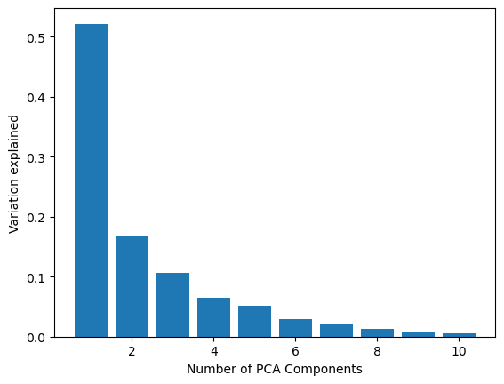

```python
#variation explained
plt.bar(list(range(1,11)),pca.explained_variance_ratio_)
plt.ylabel('Variation explained')
plt.xlabel('Number of PCA Components')
plt.show()
```

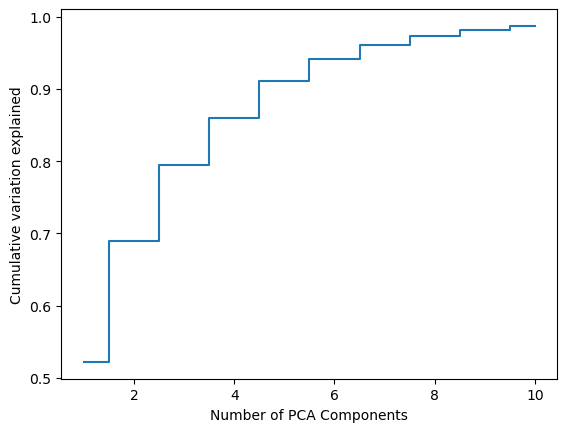

```python
#cumulative variation explained
plt.step(list(range(1,11)),np.cumsum(pca.explained_variance_ratio_), where='mid')
plt.ylabel('Cumulative variation explained')
plt.xlabel('Number of PCA Components')
plt.show()
```

##### E. Draw a horizontal line on the above plot to highlight the threshold of 90%. [1 Marks]

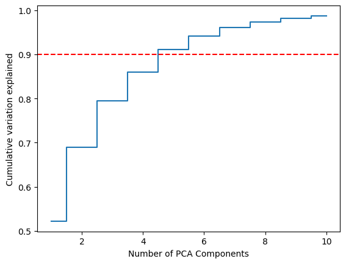

```python
#cumulative variation explained
plt.step(list(range(1,11)),np.cumsum(pca.explained_variance_ratio_), where='mid')
plt.axhline(y=0.9, color='r', linestyle='--', label='90% Threshold')  # Draw a horizontal line at y=0.9
plt.ylabel('Cumulative variation explained')
plt.xlabel('Number of PCA Components')
plt.show()
```

##### F. Apply PCA on the data. This time Select Minimum Components with 90% or above variance explained. [2 Marks]

```python
pca6 = PCA(n_components=6)
pca6.fit(XScaled)
print('Eigen Values:\n', pca6.explained_variance_)
print('Eigen Vectors:\n', pca6.components_)
print("Percentage of variation explained by each eigen vector:\n", pca6.explained_variance_ratio_)
XScaled_pca6 = pca6.transform(XScaled)
```

```
Eigen Values:
 [9.40460261 3.01492206 1.90352502 1.17993747 0.91726063 0.53999263]
Eigen Vectors:
 [[ 2.75283688e-01  2.93258469e-01  3.04609128e-01  2.67606877e-01
   8.05039890e-02  9.72756855e-02  3.17092750e-01 -3.14133155e-01
   3.13959064e-01  2.82830900e-01  3.09280359e-01  3.13788457e-01
   2.72047492e-01 -2.08137692e-02  4.14555082e-02  5.82250207e-02
   3.02795063e-02  7.41453913e-02]
 [-1.26953763e-01  1.25576727e-01 -7.29516436e-02 -1.89634378e-01
  -1.22174860e-01  1.07482875e-02  4.81181371e-02  1.27498515e-02
   5.99352482e-02  1.16220532e-01  6.22806229e-02  5.37843596e-02
   2.09233172e-01  4.88525148e-01 -5.50899716e-02 -1.24085090e-01
  -5.40914775e-01 -5.40354258e-01]
 [-1.19922479e-01 -2.48205467e-02 -5.60143254e-02  2.75074211e-01
   6.42012966e-01  5.91801304e-01 -9.76283108e-02  5.76484384e-02
  -1.09512416e-01 -1.70641987e-02  5.63239801e-02 -1.08840729e-01
  -3.14636493e-02  2.86277015e-01 -1.15679354e-01 -7.52828901e-02
   8.73592034e-03  3.95242743e-02]
 [ 7.83843562e-02  1.87337408e-01 -7.12008427e-02 -4.26053415e-02
   3.27257119e-02  3.14147277e-02 -9.57485748e-02  8.22901952e-02
  -9.24582989e-02  1.88005612e-01 -1.19844008e-01 -9.17449326e-02
   2.00095228e-01 -6.55051354e-02  6.04794251e-01 -6.66114117e-01
   1.05526253e-01  4.74890311e-02]
 [ 6.95178336e-02 -8.50649541e-02  4.06645652e-02 -4.61473712e-02
  -4.05494488e-02  2.13432566e-01 -1.54853051e-02  7.68518713e-02
   2.17633062e-03 -6.06366844e-02 -4.56472639e-04 -1.95548307e-02
  -6.15991681e-02  1.45530146e-01  7.29189842e-01  5.99196401e-01
  -1.00602332e-01 -2.98614820e-02]
 [ 1.44875476e-01 -3.02731147e-01 -1.38405774e-01  2.48136635e-01
   2.36932611e-01 -4.19330747e-01  1.16100151e-01 -1.41840113e-01
   9.80561402e-02 -4.61674973e-01  2.36225436e-01  1.57820188e-01
  -1.35576278e-01  2.41356821e-01  2.03209257e-01 -1.91960803e-01
   1.56939174e-01 -2.41222817e-01]]
Percentage of variation explained by each eigen vector:
 [0.52186034 0.16729768 0.10562639 0.0654746  0.05089869 0.02996413]
```

##### G. Train SVM model on components selected from above step. [1 Marks]

Since we have transformed features in 6 components and stored in XScaled_pca6, we will use this to build our svm model now.

```python
X_train, X_test, Y_train, Y_test = train_test_split(XScaled_pca6, Y, test_size=0.2, random_state=1, stratify=Y) #split the scaled data in 80:20 train test ratio
svcModel = SVC() #build the model
svcModel.fit(X_train, Y_train) #train the model
```

```
SVC()
```

##### H. Print Classification metrics for train data of above model and share insights. [2 Marks]

```python
train_predclass = svcModel.predict(X_train) #test the model
test_predclass = svcModel.predict(X_test) #test the model

print("Training Score:", svcModel.score(X_train, Y_train))
print("Testing Score:", svcModel.score(X_test, Y_test))

print("Train Recall Score:", metrics.recall_score(Y_train, train_predclass, average='macro'))
print("Test Recall Score:", metrics.recall_score(Y_test, test_predclass, average='macro'))

print("Train Precision Score:", metrics.precision_score(Y_train, train_predclass, average='macro'))
print("Test Precision Score:", metrics.precision_score(Y_test, test_predclass, average='macro'))

print("Train F1 Score:", metrics.f1_score(Y_train, train_predclass, average='macro'))
print("Test F1 Score:", metrics.f1_score(Y_test, test_predclass, average='macro'))

print("Train Classification Report:\n", metrics.classification_report(Y_train, train_predclass))
print("Test Classification Report:\n", metrics.classification_report(Y_test, test_predclass))
```

```
Training Score: 0.9038461538461539
Testing Score: 0.8705882352941177
Train Recall Score: 0.8980723621356713
Test Recall Score: 0.8650281888653982
Train Precision Score: 0.8993348490814482
Test Precision Score: 0.8622695589863852
Train F1 Score: 0.898564099271885
Test F1 Score: 0.8634395539357692
Train Classification Report:
               precision    recall  f1-score   support

           0       0.92      0.92      0.92       343
           1       0.90      0.87      0.89       174
           2       0.88      0.90      0.89       159

    accuracy                           0.90       676
   macro avg       0.90      0.90      0.90       676
weighted avg       0.90      0.90      0.90       676

Test Classification Report:
               precision    recall  f1-score   support

           0       0.89      0.88      0.89        86
           1       0.91      0.89      0.90        44
           2       0.79      0.82      0.80        40

    accuracy                           0.87       170
   macro avg       0.86      0.87      0.86       170
weighted avg       0.87      0.87      0.87       170
```

**Insights:**

- Overall Score from this SVM model is good. it has an average of 90% on training data for accuracy, recall, precision and f1-score and on testing data an avg of 87%.
- But Previous SVM model before PCA had better score having an average of around 98% on training data for accuracy, recall, precision and f1-score and on testing data an avg of 95%
- For this model, Training and testing data prediction score is also similar so it is not an overfit model.

##### 4. Performance Improvement: [5 Marks]

##### A. Train another SVM on the components out of PCA. Tune the parameters to improve performance. [2 Marks]

```python
from sklearn.model_selection import GridSearchCV
#XScaled_pc6 contains the transformed components with 6 columns
X_train, X_test, Y_train, Y_test = train_test_split(XScaled_pca6, Y, test_size=0.2, random_state=1, stratify=Y)

param_grid = {'C': [0.1, 1, 10],
              'gamma': [0.01, 0.1, 1],
              'kernel': ['linear', 'poly', 'rbf', 'sigmoid']}
svmGSModel = SVC()
grid_search = GridSearchCV(svmGSModel, param_grid, cv=5)
grid_search.fit(X_train, Y_train)
```

```
GridSearchCV(cv=5, estimator=SVC(),
             param_grid={'C': [0.1, 1, 10], 'gamma': [0.01, 0.1, 1],
                         'kernel': ['linear', 'poly', 'rbf', 'sigmoid']})
```

##### B. Share best Parameters observed from above step. [1 Marks]

```python
# Get the best parameters
best_params = grid_search.best_params_
print("Best Hyperparameters:", best_params)

# Get the best model
best_SVCmodel = grid_search.best_estimator_
print('Best Model', best_SVCmodel)
```

```
Best Hyperparameters: {'C': 10, 'gamma': 0.1, 'kernel': 'rbf'}
Best Model SVC(C=10, gamma=0.1)
```

##### C. Print Classification metrics for train data of above model and share relative improvement in performance in all the models along with insights. [2 Marks]

```python
train_predclass = best_SVCmodel.predict(X_train) #test the model
test_predclass = best_SVCmodel.predict(X_test) #test the model

print("Training Score:", best_SVCmodel.score(X_train, Y_train))
print("Testing Score:", best_SVCmodel.score(X_test, Y_test))

print("Train Recall Score:", metrics.recall_score(Y_train, train_predclass, average='macro'))
print("Test Recall Score:", metrics.recall_score(Y_test, test_predclass, average='macro'))

print("Train Precision Score:", metrics.precision_score(Y_train, train_predclass, average='macro'))
print("Test Precision Score:", metrics.precision_score(Y_test, test_predclass, average='macro'))

print("Train F1 Score:", metrics.f1_score(Y_train, train_predclass, average='macro'))
print("Test F1 Score:", metrics.f1_score(Y_test, test_predclass, average='macro'))

print("Train Classification Report:\n", metrics.classification_report(Y_train, train_predclass))
print("Test Classification Report:\n", metrics.classification_report(Y_test, test_predclass))
```

```
Training Score: 0.9600591715976331
Testing Score: 0.9
Train Recall Score: 0.9596428155176313
Test Recall Score: 0.9051797040169133
Train Precision Score: 0.9572262021431759
Test Precision Score: 0.8914562242278229
Train F1 Score: 0.9583314637830723
Test F1 Score: 0.8966392262254428
Train Classification Report:
               precision    recall  f1-score   support

           0       0.97      0.96      0.96       343
           1       0.96      0.95      0.96       174
           2       0.94      0.97      0.95       159

    accuracy                           0.96       676
   macro avg       0.96      0.96      0.96       676
weighted avg       0.96      0.96      0.96       676

Test Classification Report:
               precision    recall  f1-score   support

           0       0.94      0.88      0.91        86
           1       0.95      0.93      0.94        44
           2       0.78      0.90      0.84        40

    accuracy                           0.90       170
   macro avg       0.89      0.91      0.90       170
weighted avg       0.91      0.90      0.90       170
```

**Insights:**

- First SVM model before PCA had best score so far with having an average of around 98% on training data for accuracy, recall, precision and f1-score and on testing data an avg of 95%
- Second SVM model Score has an average of 90% on training data for accuracy, recall, precision and f1-score and on testing data an avg of 87%.
- 3rd SVM Model(Above one after PCA and Hyperparameter tuning), Performance scores has increased compared to second model but is less than first model.
- Current SVM model has an avg of 96% accuracy, recall, precision and f1-score on training data and 90% on testing data.
- If we look at the classification report, precision, recall and f1-score for class 0 is 94%, 88% and 91% respectively, for class 1, 95%, 93% and 94% and for class 2, it is 78%, 90% and 84% with an avg accuracy of 90%.
- Macro avg for precision, recall and f1-score is 89%, 91% and 90% respectively.
- Overall this model is also good model with good prediction score.

##### 5. Data Understanding & Cleaning: [5 Marks]

##### A. Explain pre-requisite/assumptions of PCA. [2 Marks]

PCA stands for Principal Component Analysis. PCA is an important method of feature extraction or say dimensionality reduction. It is taken into consideration when we have large number of features in the dataset and it is very difficult to visualize all those features in those many number of dimensions and it becomes very complex. So to overcome this issue, we use PCA technique.  
But there are following pre-requisite/assumptions for doing PCA which we have also done in this project:

- Data should be numerical in all features. PCA works best with numerical data. Categorical variables are typically not suitable for PCA without appropriate encoding or preprocessing.
- PCA works best when the features are scaled to have comparable variances. Scaling ensures that features with larger variances do not dominate the principal components. we can do scaling using ZScore, StandardScaler or MinMaxScaler etc.
- PCA assumes linear relationship between the underlying features in the dataset.
- PCA assumes that the principal components or say the derived features are orthogonal i.e 90 degree to each other.
- No missing values should be there for better results. we can impute the missing or unexpected values beforehand of applying PCA

##### B. Explain advantages and limitations of PCA. [3 Marks]

**Advantages of PCA:**

- PCA reduces the number of features in the dataset, making it easier to visualize, store, and analyze. This can be especially beneficial for high-dimensional datasets with many features.
- By reducing dimensions, PCA can help visualize high-dimensional data in fewer dimensions, making it easier to identify patterns and relationships.
- PCA focuses on capturing the most significant variation in the data which reduces the noise and overfitting as well.
- Models trained on PCA-reduced data is faster and be less computationally expensive becasue less data to process.

**Limitations of PCA:**

- Reducing dimensions leads to some loss of information. While PCA tries to minimize this loss, it's important to be aware of what information might be discarded.
- Data must be normalized/standardized before applying PCA
- It is difficult to Interpret Principal Components. The new features created by PCA is linear combinations of the original features, making their interpretation less intuitive compared to the original features.
- It is sensitive to scaling. Feature scaling can significantly impact the results of PCA. It's crucial to properly scale your data before applying PCA to avoid biased results.
- PCA is not suitable for all data types. PCA works best with numerical data. It's not directly applicable to categorical or text data without additional transformations.